# Predicting Users’ Barbell Lift Technique

Charles Bryan

11/7/2019

## Synopsis

The task here is to determine how barbell lifts were performed based on measurements taken from the participants doing the exercise. The barbell lifts were performed in 5 different ways by different participants where 4 of the ways were incorrect in some common manner. After looking at the provided training data it is apparent that many columns are left empty or NA, so the training data is split into two separate sets: one set with almost all columns containing data and one set with most columns containing NA or no data. Next the data is cleaned and random forests is run on the two sets. Both training models perform perfectly on their own training sets, however, they differ on the provided test set. The model trained on the larger training set performed perfectly on the provided test set, while the second model only gets 75% correct. This is likely because the large difference in observations used to train each model: 19216 for model 1 and only 406 for model 2.

## Setup

```r
require(tidyverse)
require(caret)
require(gridExtra)
require(naniar)
require(DMwR)
```

```r
set.seed(123)
# sessionInfo()
```

## Data Retrieval

First the training and test data provided below is imported: http://web.archive.org/web/20161224072740/http:/groupware.les.inf.puc-rio.br/har

**Citation:** Ugulino, W.; Cardador, D.; Vega, K.; Velloso, E.; Milidiu, R.; Fuks, H. Wearable Computing: Accelerometers’ Data Classification of Body Postures and Movements. Proceedings of 21st Brazilian Symposium on Artificial Intelligence. Advances in Artificial Intelligence - SBIA 2012. In: Lecture Notes in Computer Science. , pp. 52-61. Curitiba, PR: Springer Berlin / Heidelberg, 2012. ISBN 978-3-642-34458-9. DOI: 10.1007/978-3-642-34459-6_6.

```r
if(!file.exists("./data")){dir.create("./data")}

# Weight Lifting Exercise Dataset (Separated into training and testing sets)
dataTrainUrl <- "https://d396qusza40orc.cloudfront.net/predmachlearn/pml-training.csv"
TrainfileName <- "./data/WeightliftTraining.csv"
if(!file.exists(TrainfileName)){download.file(dataTrainUrl, destfile=TrainfileName)}

dataTestUrl <- "https://d396qusza40orc.cloudfront.net/predmachlearn/pml-testing.csv"
TestfileName <- "./data/WeightliftTesting.csv"
if(!file.exists(TestfileName)){download.file(dataTestUrl, destfile=TestfileName)}

training_raw <- read.csv(TrainfileName)
testing_raw <- read.csv(TestfileName)
```

## Data Cleaning and Exploratory Analysis

The test data provided is not time sequential, as in multiple observations can not be used together to predict the exercise method. Based on this, no time related columns are going to be helpful. Therefore, these columns are removed from both the training and testing sets.

```r
training_sub <- subset(training_raw,select=-c(X, user_name,raw_timestamp_part_1,
                                              raw_timestamp_part_2,
                                              cvtd_timestamp, new_window,
                                              num_window))
testing_sub <- subset(testing_raw, select=-c(X, user_name,raw_timestamp_part_1,
                                             raw_timestamp_part_2,
                                             cvtd_timestamp, new_window,
                                             num_window))
```

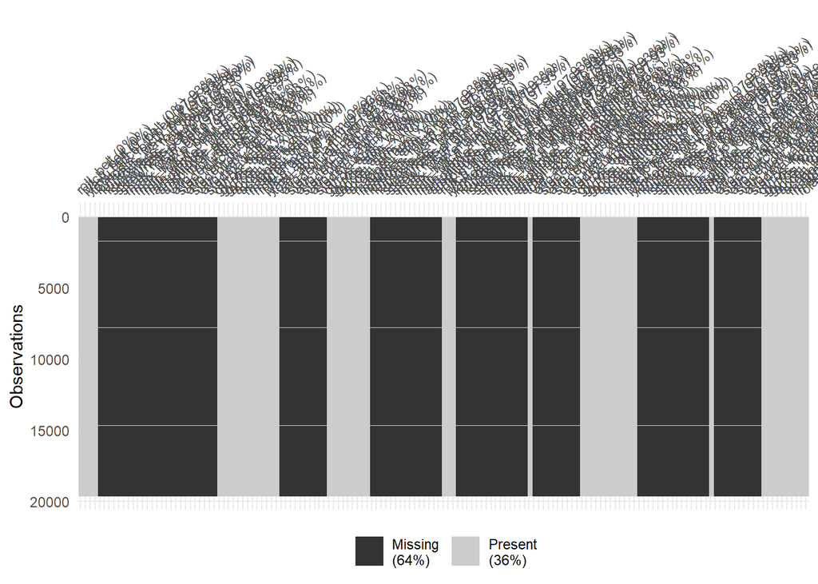

```r
training_temp <- data.frame(lapply(training_sub, function(x) {gsub("^$", NA, x)}))
vis_miss(training_temp, warn_large_data = FALSE)
```

This data set has a few different types of errors: Occurrences of "“, NA, and DIV/0. In total there are 19622 observations. Exactly 19216 of these rows have either”" or NA in many of the cells while the remaining 406 observations have DIV/0 errors in some of their cells. It appears that for these 406 rows additional information was calculated and the method used to calculate some values gave a DIV/0 error in those cases.

```r
na_rows <- apply(training_temp, 1, function(r) any(r %in% c(NA)))

classeCount <- training_temp %>% group_by(classe) %>% summarise(no_rows = length(classe))
classeCountNoNA <- training_temp[!na_rows,] %>%
  group_by(classe) %>%summarise(no_rows=length(classe))

classeCountNoNA$no_rows/classeCount$no_rows
```

```
## [1] 0.01953405 0.02080590 0.02045587 0.02145522 0.02190186
```

Interestingly each of the 5 classes is impacted by the NA errors relatively similarly. If one class was more significantly impacted we would need to take that into account.

We will divide the dataset up into two sets, the 406 rows with this additional info (training_sub_div) and the 19216 rows that do not (training_sub_na). This is done in case these additional features prove to be useful in classifying the exercises.

```r
training_sub_na <- training_temp[na_rows,]
training_sub_div <- training_temp[!na_rows,]
```

Now to clean up the data some:

- Filter out columns that only have 1 value since this information is not helpful in classification.
- Convert all columns other than the classe label into numeric variables.
- In the training_sub_div dataset, convert the “DIV/0!” error into NA to more easily work with.

```r
# Update Factor Levels based on the current dataframe, not the original
training_sub_na[] <- lapply(training_sub_na, function(x) if(is.factor(x)) factor(x) else x)
# Remove Columns with only 1 Factor level. These columns will not contribute to a model.
training_sub_na <- training_sub_na[, sapply(training_sub_na, function(col) length(unique(col))) > 1]
# Convert all columns to type numeric except the classe label
names_na <- colnames(training_sub_na)
names_na <- names_na[!names_na %in% c("classe")]
training_sub_na[names_na] <- lapply(training_sub_na[names_na],
                                           function(x) as.numeric(levels(x))[x])

# Replace DIV/0 error with NA
training_sub_div <- data.frame(lapply(training_sub_div, function(x) {gsub("#DIV/0!", NA, x)}))
# Update Factor Levels based on the current dataframe, not the original
training_sub_div[] <- lapply(training_sub_div, function(x) if(is.factor(x)) factor(x) else x)
# Remove Columns with only 1 Factor level. These columns will not contribute to a model.
training_sub_div <- training_sub_div[, sapply(training_sub_div, function(col){
  length(levels(col))}) > 1]
```

Some values in the training_sub_div dataset are still missing as shown below:

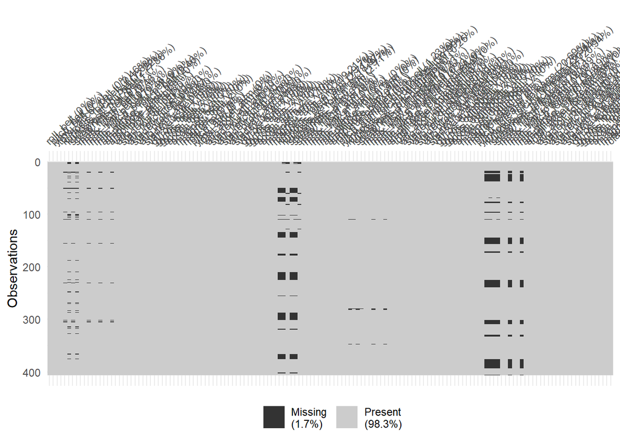

```r
vis_miss(training_sub_div, warn_large_data = FALSE)
```

These rows with missing data make up a significant portion of the 406 observations in this set, so idealy they would not be removed. These missing values are numeric, so imputing the values using default knn is appropriate.

```r
training_sub_div_clean <- knnImputation(training_sub_div, k = 10, scale = T,
                                        meth = "weighAvg", distData = training_sub_div)
```

As before, the dataset is cleaned of any columns that have only one value and also all features are converted to numeric other than the classe labels.

```r
# Convert all but the classe label from Factor to numeric
names_div <- colnames(training_sub_div_clean)
names_div <- names_div[!names_div %in% c("classe")]
training_sub_div_clean[names_div] <- lapply(training_sub_div_clean[names_div],
                                            function(x) as.numeric(levels(x))[x])

# Remove Columns with only 1 Numeric value. This ends up only being the column
# "amplitude_yaw_dumbbell" with only the value 0
training_sub_div_clean <- training_sub_div_clean[, sapply(training_sub_div_clean, function(col){length(unique(col))}) > 1]
```

I used the following method to plot histograms of each variable to visually find any outliers. Unfortunately due to the amount of features the plot does not fit well in one viewing.

```r
 training_sub_div_clean %>%
  keep(is.numeric) %>%
  gather() %>%
  ggplot(aes(value)) +
    facet_wrap(~ key, scales = "free") +
    geom_histogram()
```

[output not shown]

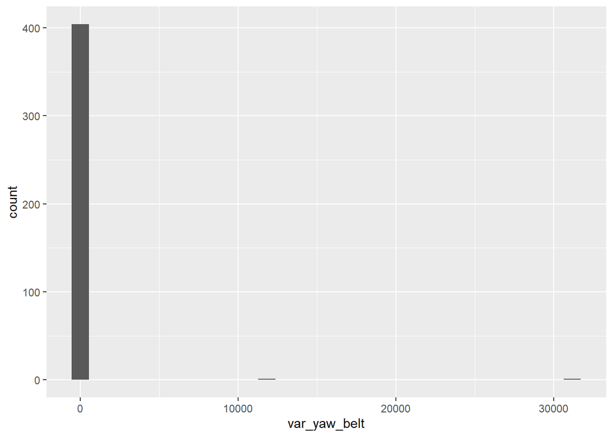

```r
ggplot(data=training_sub_div_clean, aes(x=var_yaw_belt)) + geom_histogram()
```

Based on the plots and further inspecting the data, some outliers of each dataset are filtered using the following criteria:

```r
training_na_filter <- training_sub_na %>%
  filter(magnet_belt_x < 350) %>%
  filter(magnet_belt_z < 100) %>%
  filter(gyros_forearm_z > -6) %>%
  filter(gyros_dumbbell_x > -100) %>%
  filter(magnet_dumbbell_y > -2000)
```

```r
training_div_filter <- training_sub_div_clean %>%
  filter(amplitude_roll_belt < 300) %>%
  filter(kurtosis_picth_arm < 15) %>%
  filter(kurtosis_picth_dumbbell < 40) %>%
  filter(kurtosis_roll_arm < 15) %>%
  filter(kurtosis_roll_belt < 30) %>%
  filter(kurtosis_roll_dumbbell < 40) %>%
  filter(kurtosis_roll_forearm < 30) %>%
  filter(magnet_belt_x < 350) %>%
  filter(magnet_belt_z < 100) %>%
  filter(max_yaw_belt < 30) %>%
  filter(max_yaw_dumbbell < 40) %>%
  filter(max_yaw_forearm < 40) %>%
  filter(min_yaw_dumbbell < 40) %>%
  filter(min_yaw_forearm < 30) %>%
  filter(stddev_roll_arm < 150) %>%
  filter(stddev_yaw_belt < 80) %>%
  filter(var_accel_dumbbell < 100) %>%
  filter(var_pitch_dumbbell < 6000) %>%
  filter(var_roll_arm < 20000) %>%
  filter(var_yaw_arm < 15000) %>%
  filter(var_yaw_belt < 60) %>%
  filter(var_yaw_dumbbell < 7000) %>%
  filter(gyros_forearm_z > -6) %>%
  filter(gyros_dumbbell_x > -100) %>%
  filter(magnet_dumbbell_y > -2000)
```

## Modeling

```r
testing_columns <- colnames(testing_sub[1,!sapply(testing_sub, function(x)all(is.na(x)))])
length(testing_columns)
```

```
## [1] 53
```

Only 53 of the original columns are actually usable.

Two models are built using using random forests and 10-fold cross validation.

modFit1 will be using the large dataset of 19216 observations which removed all of the features that contained NAs. The model is only trained with the columns shared between this set and the testing set.

```r
training_na_columns <- colnames(training_na_filter)
training_na_intersection <- intersect(testing_columns, training_na_columns)

#Setup our cross validation. We will use this in model2 as well
train_control<- trainControl(method="cv", number=10)

modFit1 <- train(classe~.,
                 data=training_na_filter[,c(training_na_intersection, "classe")],
                 trControl=train_control,
                 method="rf")

training_predict1 <- predict(modFit1)
sum(training_predict1 == training_na_filter[,"classe"])/length(training_predict1)
```

```
## [1] 1
```

This model had almost perfect accuracy on its training set of 19216 observations with a very low OOB estimate of error rate of 0.44%.

```r
modFit1$finalModel$confusion
```

```
##      A    B    C    D    E  class.error
## A 5467    1    0    0    0 0.0001828822
## B   12 3702    3    0    0 0.0040355125
## C    0   22 3330    0    0 0.0065632458
## D    0    0   42 3103    2 0.0139815697
## E    0    0    0    4 3447 0.0011590843
```

Similarly modFit2 is built using the dataset of 406 observations and 10-fold cross validation. This dataset has the additional columns that were not present for the 19216 observations above. However, the model can only be trained on features shared between this dataset and the testing set.

```r
training_div_columns <- colnames(training_div_filter)
training_div_intersection <- intersect(testing_columns, training_div_columns)

modFit2 <- train(classe~.,
                 data=training_div_filter[,c(training_div_intersection, "classe")],
                 trControl=train_control,
                 method="rf")

training_predict2 <- predict(modFit2)
sum(training_predict2 == training_div_filter[,"classe"])/length(training_predict2)
```

```
## [1] 1
```

```r
modFit2$finalModel$confusion
```

```
##    A  B  C  D  E class.error
## A 89  5  2  5  0   0.1188119
## B  7 51  9  4  1   0.2916667
## C  5  1 61  2  1   0.1285714
## D  3  4 10 47  2   0.2878788
## E  1 11  5  2 57   0.2500000
```

Each model is now run on the testing set.

```r
testing_predict1 <- predict(modFit1, newdata = testing_sub[,training_na_intersection])
testing_predict2 <- predict(modFit2, newdata = testing_sub[,training_div_intersection])
```

The results our two models’ predictions can be compared.

```r
sum(testing_predict1==testing_predict2)/length(testing_predict1)
```

```
## [1] 0.75
```

It appears that the predictions were the same for only 75% of the testing observations. For the 20 quiz questions I used the results from the larger set as it was more reliable based on the model error estimates and the sheer number of observations used for training. This model received a perfect score on the limited test set provided.

## Conclusions

1. I would expect little error when using modFit1 based on the very low error estimate, however, I would expect a large error rate using the second model.
2. Looking back at the steps I took for data cleaning, I should not have split the data based into a group of 19216 and 406 observations. This was done thinking the extra features would be helpful in the dataset of 406, however, the test set did not contian the additional features provided by this set making them no more helpful.